# Applied Statistics Assignment

## **1. Impoting the necessary libraries**

```python
import pandas as pd
import numpy as np
import matplotlib.pyplot as plt
import seaborn as sns
sns.set(color_codes=True)
```

## **2. Reading the data as a dataframe named as "insurance"**

```python
insurance = pd.read_csv("insurance.csv")
```

## **3. Basic EDA**

**Reading the top 5 rows of the data set**

```python
insurance.head()
```

|  | age | sex | bmi | children | smoker | region | charges |
| --- | --- | --- | --- | --- | --- | --- | --- |
| 0 | 19 | female | 27.900 | 0 | yes | southwest | 16884.92400 |
| 1 | 18 | male | 33.770 | 1 | no | southeast | 1725.55230 |
| 2 | 28 | male | 33.000 | 3 | no | southeast | 4449.46200 |
| 3 | 33 | male | 22.705 | 0 | no | northwest | 21984.47061 |
| 4 | 32 | male | 28.880 | 0 | no | northwest | 3866.85520 |

**Reading the bottom 5 rows of the data set**

```python
insurance.tail()
```

|  | age | sex | bmi | children | smoker | region | charges |
| --- | --- | --- | --- | --- | --- | --- | --- |
| 1333 | 50 | male | 30.97 | 3 | no | northwest | 10600.5483 |
| 1334 | 18 | female | 31.92 | 0 | no | northeast | 2205.9808 |
| 1335 | 18 | female | 36.85 | 0 | no | southeast | 1629.8335 |
| 1336 | 21 | female | 25.80 | 0 | no | southwest | 2007.9450 |
| 1337 | 61 | female | 29.07 | 0 | yes | northwest | 29141.3603 |

### a. Shape of the data

```python
insurance.shape
```

```
(1338, 7)
```

**Observation :**

The data set has got 1338 rows and 7 columns

### b. Data type of each of the 7 attributes present in the data set

```python
insurance.info()
```

```
<class 'pandas.core.frame.DataFrame'>
RangeIndex: 1338 entries, 0 to 1337
Data columns (total 7 columns):
 #   Column    Non-Null Count  Dtype
---  ------    --------------  -----
 0   age       1338 non-null   int64
 1   sex       1338 non-null   object
 2   bmi       1338 non-null   float64
 3   children  1338 non-null   int64
 4   smoker    1338 non-null   object
 5   region    1338 non-null   object
 6   charges   1338 non-null   float64
dtypes: float64(2), int64(2), object(3)
memory usage: 73.3+ KB
```

**Observations :**

1) The insurance data set has got the following numeric columns : age(integer, 64-bit), bmi(float, 64-bit), children(integer,64-bit), charges(float,64-bit)

2) The insurance data set has got the following non-numeric columns : sex(string), smoker(string), region(string)

**A quick check on the number of different data points present for each of the seven attributes :**

```python
insurance.nunique()
```

```
age           47
sex            2
bmi          548
children       6
smoker         2
region         4
charges     1337
dtype: int64
```

**Observation:**

sex, children, smoker and region can be treated as categorical variables

### c. Checking the presence of missing values

```python
insurance.isnull().sum()
```

```
age         0
sex         0
bmi         0
children    0
smoker      0
region      0
charges     0
dtype: int64
```

**Observation :**

From the output above we can see that none of the columns have got any missing values

## A quick look at the 5 number summary of the data

### d. 5 point summary of numerical attributes

```python
stats = insurance.describe()
stats = stats[['age','bmi','charges']]
stats
```

|  | age | bmi | charges |
| --- | --- | --- | --- |
| count | 1338.000000 | 1338.000000 | 1338.000000 |
| mean | 39.207025 | 30.663397 | 13270.422265 |
| std | 14.049960 | 6.098187 | 12110.011237 |
| min | 18.000000 | 15.960000 | 1121.873900 |
| 25% | 27.000000 | 26.296250 | 4740.287150 |
| 50% | 39.000000 | 30.400000 | 9382.033000 |
| 75% | 51.000000 | 34.693750 | 16639.912515 |
| max | 64.000000 | 53.130000 | 63770.428010 |

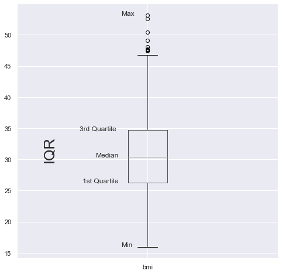

```python
insurance.boxplot(column="bmi",return_type='axes',figsize=(8,8))
plt.text(x=0.74, y=stats.loc['75%','bmi'], s="3rd Quartile")
plt.text(x=0.8, y=stats.loc['50%','bmi'], s="Median")
plt.text(x=0.75,y=stats.loc['25%','bmi'], s="1st Quartile")
plt.text(x=0.9, y=stats.loc['min','bmi'], s="Min")
plt.text(x=0.9, y=stats.loc['max','bmi'], s="Max")
plt.text(x=0.6, y=30, s="IQR", rotation=90, size=25)
```

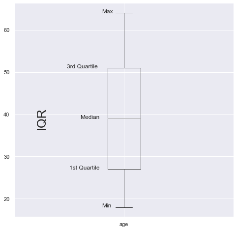

```python
insurance.boxplot(column="age",return_type='axes',figsize=(8,8))
plt.text(x=0.74, y=stats.loc['75%','age'], s="3rd Quartile")
plt.text(x=0.8, y=stats.loc['50%','age'], s="Median")
plt.text(x=0.75, y=stats.loc['25%','age'], s="1st Quartile")
plt.text(x=0.9, y=stats.loc['min','age'], s="Min")
plt.text(x=0.9, y=stats.loc['max','age'], s="Max")
plt.text(x=0.6, y=37, s="IQR", rotation=90, size=25)
```

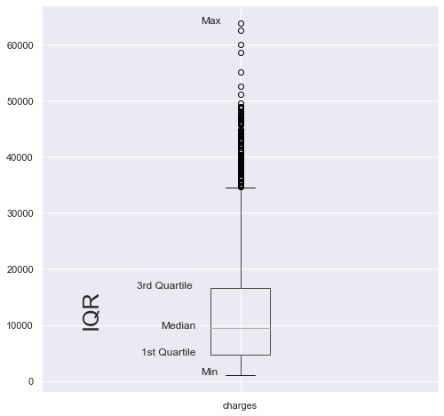

```python
insurance.boxplot(column="charges",return_type='axes',figsize=(8,8))
plt.text(x=0.74, y=stats.loc['75%','charges'], s="3rd Quartile")
plt.text(x=0.8, y=stats.loc['50%','charges'], s="Median")
plt.text(x=0.75, y=stats.loc['25%','charges'], s="1st Quartile")
plt.text(x=0.9, y=stats.loc['min','charges'], s="Min")
plt.text(x=0.9, y=stats.loc['max','charges'], s="Max")
plt.text(x=0.6, y=9980, s="IQR", rotation=90, size=25)
```

### e. Distribution of "bmi", "age" and "charge" columns

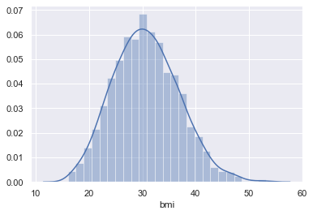

```python
sns.distplot(insurance['bmi'])
```

**Observation :**

From the distribution of bmi, we can see that, it is normally distributed with average being centered at 30.663397 kg/m^2

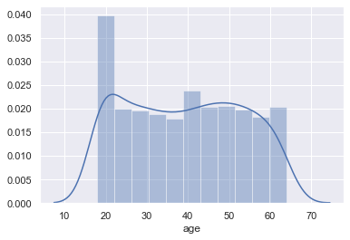

```python
sns.distplot(insurance['age'])
```

**Observation:**

The distribution of age seems to be bimodal.

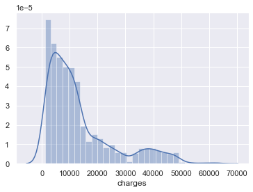

```python
sns.distplot(insurance['charges'])
```

**Observation:**

From the distribution of charges, we can see that the data points are skewed more towards the right as the mean value(13270.422) is greater than the median value(9382).

### f. Measure of skewness of ‘bmi’, ‘age’ and ‘charges’ columns

```python
insurance[['bmi','age','charges']].skew()
```

```
bmi        0.284047
age        0.055673
charges    1.515880
dtype: float64
```

**Observation:**

Even from the histrograms of bmi,age and charges columns, we saw that the charges column is more skewed towards the right hand side.

### g. Checking the presence of outliers in ‘bmi’, ‘age’ and ‘charges columns

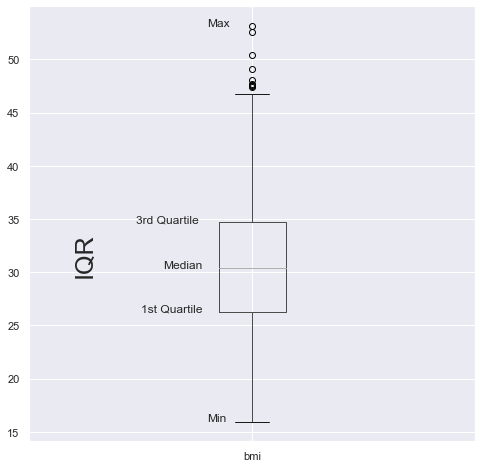

```python
insurance.boxplot(column="bmi",return_type='axes',figsize=(8,8))
plt.text(x=0.74, y=stats.loc['75%','bmi'], s="3rd Quartile")
plt.text(x=0.8, y=stats.loc['50%','bmi'], s="Median")
plt.text(x=0.75,y=stats.loc['25%','bmi'], s="1st Quartile")
plt.text(x=0.9, y=stats.loc['min','bmi'], s="Min")
plt.text(x=0.9, y=stats.loc['max','bmi'], s="Max")
plt.text(x=0.6, y=30, s="IQR", rotation=90, size=25)
```

```python
iqr = stats.loc['75%','bmi']-stats.loc['25%','bmi']
outlier = (1.5*iqr) + stats.loc['75%','bmi']
outlier
```

```
47.290000000000006
```

**Observation:**

We can see the outliers present for bmi at a value above 47.3 kg/m^2

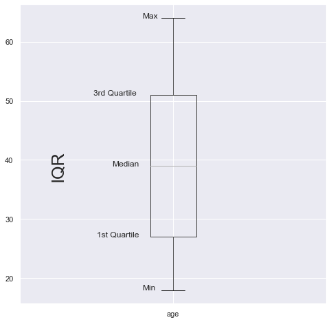

```python
insurance.boxplot(column="age",return_type='axes',figsize=(8,8))
plt.text(x=0.74, y=stats.loc['75%','age'], s="3rd Quartile")
plt.text(x=0.8, y=stats.loc['50%','age'], s="Median")
plt.text(x=0.75, y=stats.loc['25%','age'], s="1st Quartile")
plt.text(x=0.9, y=stats.loc['min','age'], s="Min")
plt.text(x=0.9, y=stats.loc['max','age'], s="Max")
plt.text(x=0.6, y=37, s="IQR", rotation=90, size=25)
```

**Observation:**

The data in the age column looks clean with no significant outliers.

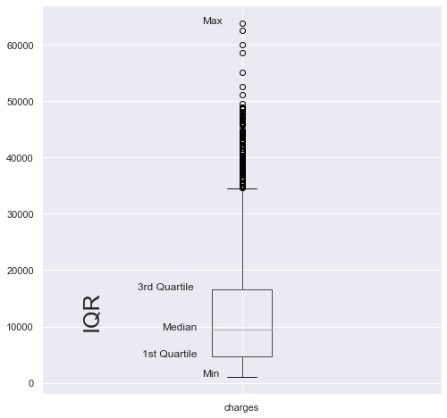

```python
insurance.boxplot(column="charges",return_type='axes',figsize=(8,8))
plt.text(x=0.74, y=stats.loc['75%','charges'], s="3rd Quartile")
plt.text(x=0.8, y=stats.loc['50%','charges'], s="Median")
plt.text(x=0.75, y=stats.loc['25%','charges'], s="1st Quartile")
plt.text(x=0.9, y=stats.loc['min','charges'], s="Min")
plt.text(x=0.9, y=stats.loc['max','charges'], s="Max")
plt.text(x=0.6, y=9980, s="IQR", rotation=90, size=25)
```

```python
iqr = stats.loc['75%','charges']-stats.loc['25%','charges']
outlier = (1.5*iqr) + stats.loc['75%','charges']
outlier
```

```
34489.350562499996
```

**Observation:**

There seems to be outliers present above the maximum value, above 34489.35 rupees.

### h. Distribution of categorical columns

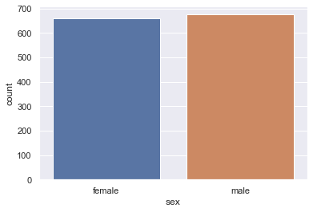

```python
sns.countplot(insurance['sex'])
```

```python
print('The number of female contractors is: '+str(insurance[insurance['sex']=='female']['sex'].count()))
```

```
The number of female contractors is: 662
```

```python
print('The number of male contractors is: '+str(insurance[insurance['sex']=='male']['sex'].count()))
```

```
The number of male contractors is: 676
```

**Observation:**

The number of female contractors(662) is less than the number of male contractors(676)

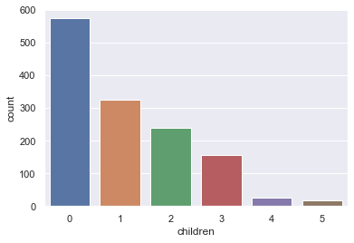

```python
sns.countplot(insurance['children'])
```

```python
print('The number of contractors with no children is: '+str(insurance[insurance['children']==0]['children'].count()))
```

```
The number of contractors with no children is: 574
```

```python
print('The number of contractors with 1 child is: '+str(insurance[insurance['children']==1]['children'].count()))
```

```
The number of contractors with 1 child is: 324
```

**Observation:**

Majority of the contractors have no children or only one child.

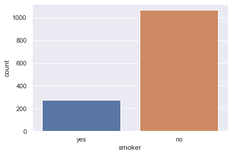

```python
sns.countplot(insurance['smoker'])
```

```python
print('The number of contractors who are smokers is: '+ str(insurance[insurance['smoker']=='yes']['smoker'].count()))
```

```
The number of contractors who are smokers is: 274
```

```python
print('The number of contractors who are non - smokers is: '+ str(insurance[insurance['smoker']=='no']['smoker'].count()))
```

```
The number of contractors who are non - smokers is: 1064
```

```python
smoker_percentage = 274/len(insurance)
smoker_percentage
```

```
0.20478325859491778
```

```python
non_smoker_percentage = 1064/len(insurance)
non_smoker_percentage
```

```
0.7952167414050823
```

**Observation:**

Majority of the contractors(about 80%) are non-smokers.

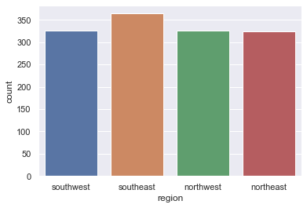

```python
sns.countplot(insurance['region'])
```

```python
insurance['region'].value_counts()
```

```
southeast    364
northwest    325
southwest    325
northeast    324
Name: region, dtype: int64
```

**Observation:**

### i. Pair plot that includes all the columns of the data frame

```python
list_of_columns = insurance.columns.to_list()
```

```python
list_of_columns
```

```
['age', 'sex', 'bmi', 'children', 'smoker', 'region', 'charges']
```

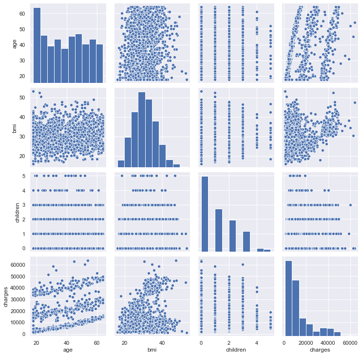

```python
sns.pairplot(insurance[list_of_columns])
```

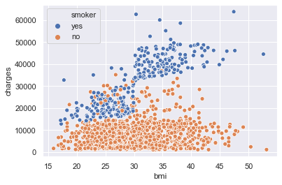

```python
sns.scatterplot(x=insurance['bmi'],y=insurance['charges'],hue=insurance['smoker'])
```

**Observation:**

We can observe from the scatter plot above that the charges are "significantly" more from smokers than non-smokers especially for smokers whose bmi lies between 30 and 47.

## **4. Answer the following questions with statistical evidence**

### a. Do charges of people who smoke differ significantly from the people who don't?

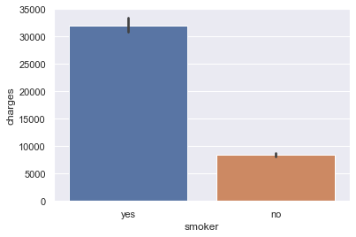

```python
sns.barplot(x=insurance['smoker'],y=insurance['charges'])
```

```python
ins_smoker = insurance[insurance['smoker']=='yes']
ins_non_smoker = insurance[insurance['smoker']=='no']
```

```python
ins_smoker.describe()
```

|  | age | bmi | children | charges |
| --- | --- | --- | --- | --- |
| count | 274.000000 | 274.000000 | 274.000000 | 274.000000 |
| mean | 38.514599 | 30.708449 | 1.113139 | 32050.231832 |
| std | 13.923186 | 6.318644 | 1.157066 | 11541.547176 |
| min | 18.000000 | 17.195000 | 0.000000 | 12829.455100 |
| 25% | 27.000000 | 26.083750 | 0.000000 | 20826.244213 |
| 50% | 38.000000 | 30.447500 | 1.000000 | 34456.348450 |
| 75% | 49.000000 | 35.200000 | 2.000000 | 41019.207275 |
| max | 64.000000 | 52.580000 | 5.000000 | 63770.428010 |

```python
ins_non_smoker.describe()
```

|  | age | bmi | children | charges |
| --- | --- | --- | --- | --- |
| count | 1064.000000 | 1064.000000 | 1064.000000 | 1064.000000 |
| mean | 39.385338 | 30.651795 | 1.090226 | 8434.268298 |
| std | 14.083410 | 6.043111 | 1.218136 | 5993.781819 |
| min | 18.000000 | 15.960000 | 0.000000 | 1121.873900 |
| 25% | 26.750000 | 26.315000 | 0.000000 | 3986.438700 |
| 50% | 40.000000 | 30.352500 | 1.000000 | 7345.405300 |
| 75% | 52.000000 | 34.430000 | 2.000000 | 11362.887050 |
| max | 64.000000 | 53.130000 | 5.000000 | 36910.608030 |

**Observation:**

Yes, the smokers are charged more than the non-smokers. On an average, the smokers are charged 32050.231832 and the non-smokers are charged 8434.268298.

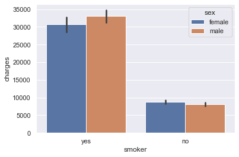

```python
sns.barplot(x=insurance['smoker'],y=insurance['charges'],hue=insurance['sex'])
```

**Observation:**

The female smokers are charged less than the male smokers. While on the other hand, the female non-smokers are charged more than the male non-smokers.

### b. Does bmi of males differ significantly from that of females?

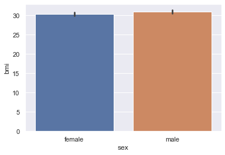

```python
sns.barplot(x=insurance['sex'],y=insurance['bmi'])
```

```python
insurance[insurance['sex']=='female']['bmi'].describe()
```

```
count    662.000000
mean      30.377749
std        6.046023
min       16.815000
25%       26.125000
50%       30.107500
75%       34.313750
max       48.070000
Name: bmi, dtype: float64
```

```python
insurance[insurance['sex']=='male']['bmi'].describe()
```

```
count    676.000000
mean      30.943129
std        6.140435
min       15.960000
25%       26.410000
50%       30.687500
75%       34.992500
max       53.130000
Name: bmi, dtype: float64
```

**Observation:**

No, there is no significant difference in the bmi for males and females. On an average, the bmi of both male and female contractors are 30 kg/m^2.

### c. Is the proportion of smokers significantly different in different genders?

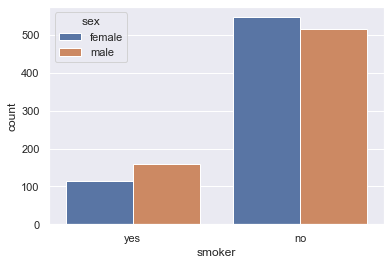

```python
sns.countplot(insurance['smoker'],hue=insurance['sex'])
```

```python
insurance[insurance['smoker']=='yes']['sex'].value_counts()
```

```
male      159
female    115
Name: sex, dtype: int64
```

```python
ratio_female_to_male = 115/(115+159)
ratio_female_to_male
```

```
0.4197080291970803
```

```python
insurance[insurance['smoker']=='no']['sex'].value_counts()
```

```
female    547
male      517
Name: sex, dtype: int64
```

```python
ratio_female_to_male = 547/(547+517)
ratio_female_to_male
```

```
0.5140977443609023
```

**Observations:**

1)The number of male smokers is more than the female smokers.About 42% of the smokers are females.

### d. Is the distributions of bmi across women with no children, one child and two children, the same?

```python
female = insurance[insurance['sex']=='female']
```

```python
female_no_children = female[female['children']==0]
female_one_child = female[female['children']==1]
female_two_children = female[female['children']==2]
```

```python
female_no_children.describe()['bmi']
```

```
count    289.000000
mean      30.361522
std        5.966934
min       17.290000
25%       26.200000
50%       29.925000
75%       34.600000
max       47.410000
Name: bmi, dtype: float64
```

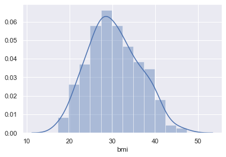

```python
sns.distplot(female_no_children['bmi'])
```

```python
female_one_child.describe()['bmi']
```

```
count    158.000000
mean      30.052658
std        5.786831
min       16.815000
25%       25.982500
50%       29.567500
75%       33.942500
max       46.090000
Name: bmi, dtype: float64
```

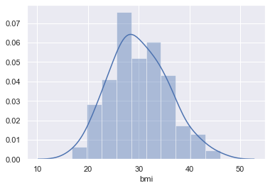

```python
sns.distplot(female_one_child['bmi'])
```

```python
female_two_children.describe()['bmi']
```

```
count    119.00000
mean      30.64979
std        6.62820
min       17.19500
25%       25.77000
50%       31.30000
75%       34.75000
max       48.07000
Name: bmi, dtype: float64
```

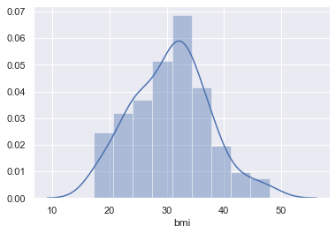

```python
sns.distplot(female_two_children['bmi'])
```

**Observations:**

1)On an average, the female contractors with no children and one child have their bmi as 30 kg/m^2 while the female contractors with two children have their bmi as 31 kg/m^2. So, there is no significant diffrences in the mean values.

3)The range(max-min) and the values of the lower and upper quartiles and median are more or less the same for the three distributions.

Hence, we can conclude that the distributions of bmi across women with no children, one child and two children are the same.The distributions more or less follow the normal distribution.